# Introduction to Point Pattern Analysis

Cargo librerias

```r
library(spatstat.core)
library(plotly)
```

Principio de Aceptacion-Rechazo para un Proceso Binomial

```r
# Graficacion
cuadri <- function(x, y){sqrt(x^2+y^2)/sqrt(8)} # Funcion de intensidad, toma valores entre 0 y 1
n<-10 # cant de datos
x <- y <- seq(0, 2, length= n)
xx<-rep(x,n)
yy<-rep(y,rep(n,n))
cbind(xx,yy) # grilla en el soporte
```

```
              xx        yy
  [1,] 0.0000000 0.0000000
  [2,] 0.2222222 0.0000000
  [3,] 0.4444444 0.0000000
  [4,] 0.6666667 0.0000000
  [5,] 0.8888889 0.0000000
  [6,] 1.1111111 0.0000000
  [7,] 1.3333333 0.0000000
  [8,] 1.5555556 0.0000000
  [9,] 1.7777778 0.0000000
 [10,] 2.0000000 0.0000000
 [11,] 0.0000000 0.2222222
 [12,] 0.2222222 0.2222222
 [13,] 0.4444444 0.2222222
 [14,] 0.6666667 0.2222222
```

[output cut: 86 more lines]

```r
z <- outer(x, y, cuadri) # intensidad calculada en cada punto de grilla
u<-runif(n*n) # puntos aleatorios x y
graf<-persp(x, y, z,theta = 65,phi=25,zlab="u")
cumplen<-(u<z) # restricción para simular bajo la intensidad
points(trans3d(xx, yy, u,pmat=graf), col = 2+cumplen, pch = 16)
```

```r
#  Simulacion
set.seed(1) # fijo la semilla
cant<-1000 # cant de obs
x<-runif(cant,0,2) # genero x entre 0 y 2
y<-runif(cant,0,2) # genero y entre 0 y 2
u<-runif(cant,0,1) # generu u entre 0 y 1
z<-cuadri(x,y) # evaluo en la funcion de intensidad
cumplen<-(u<z) # Restriccion
sum(cumplen) # cuantos quedan
```

```
[1] 554
```

[figure not shown]

```r
# Grafico 100 casos
par(pty="s")
```

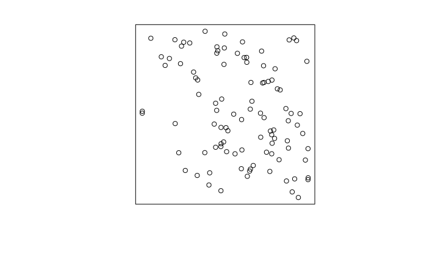

```r
plot(x[cumplen][1:100],y[cumplen][1:100],xlab = "",ylab="",xaxt='n',yaxt='n')
# Grafico todos los casos
par(pty="s")
```

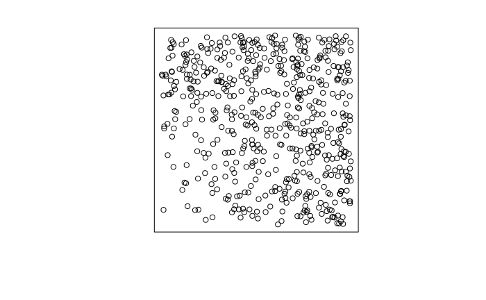

```r
plot(x[cumplen],y[cumplen],xlab = "",ylab="",xaxt='n',yaxt='n')
```

Simulacion de Complete Spatial Randomness (CSR) o Independent Random Process (IRP)

(Uniform) Binomial Point Process

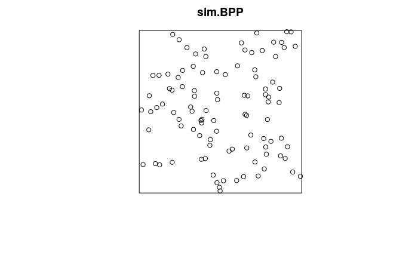

```r
set.seed(1)
cant<-100
sim.BPP<-runifpoint(cant)
plot(sim.BPP)
```

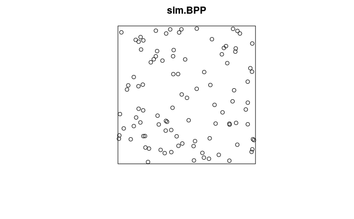

```r
set.seed(2)
sim.BPP<-runifpoint(cant)
plot(sim.BPP)
```

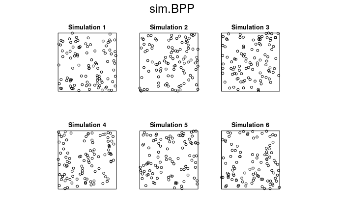

```r
# muchas realizaciones
sim.BPP<-runifpoint(cant,nsim = 6)
plot(sim.BPP)
```

Proceso de poisson homogeneo

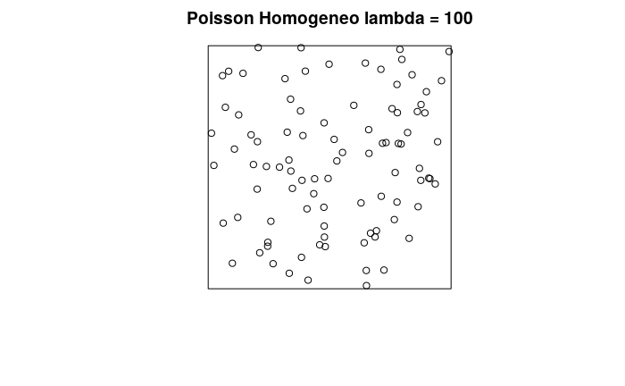

```r
set.seed(1)
lambda<-100
sim.CSR<-rpoispp(lambda)
plot(sim.CSR,main = paste("Poisson Homogeneo lambda =",lambda))
```

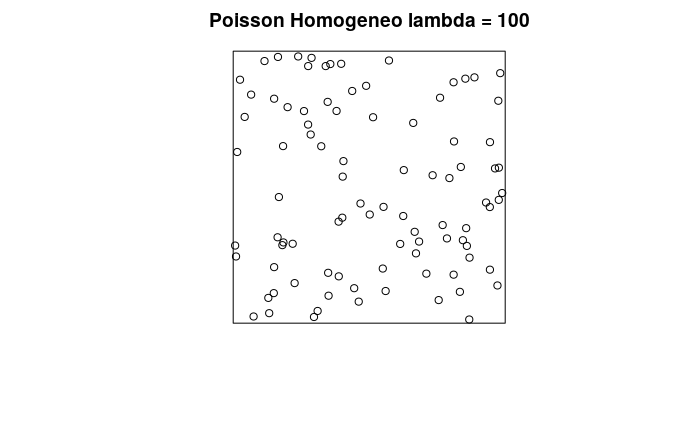

```r
set.seed(2)
lambda<-100
sim.CSR<-rpoispp(lambda)
plot(sim.CSR,main = paste("Poisson Homogeneo lambda =",lambda))
```

Proceso de poisson INhomogeneo

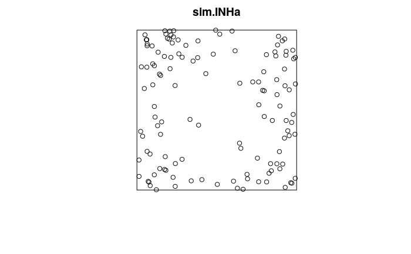

```r
set.seed(1)
sim.INHa <- rpoispp(function(x,y) {800*(x-0.5)^2 + 800*(y-0.5)^2},nsim=1)
plot(sim.INHa)
```

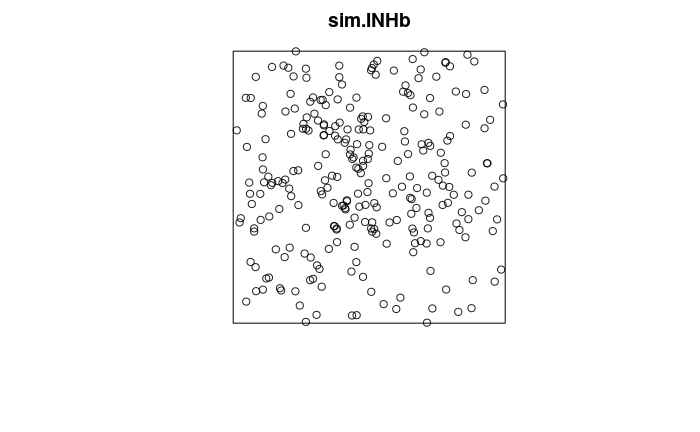

```r
set.seed(1)
sim.INHb <- rpoispp(function(x,y) {200-800*(x-0.5)^2 + 200-800*(y-0.5)^2},nsim=1)
plot(sim.INHb)
```

Procesos de Superposición (Poisson)

```r
plot(sim.INHa,type="n",main="Superposición")
points(sim.INHa,col="blue")
```

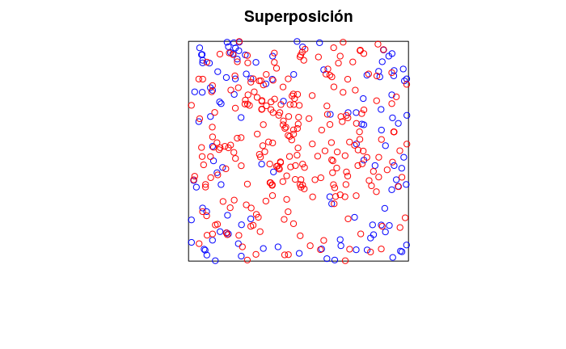

```r
points(sim.INHb,col="red")
```

Analisis de Concentracion PP Homogeneo

```r
# El proceso CSR
sim.CSR
```

```
Planar point pattern: 91 points
window: rectangle = [0, 1] x [0, 1] units
```

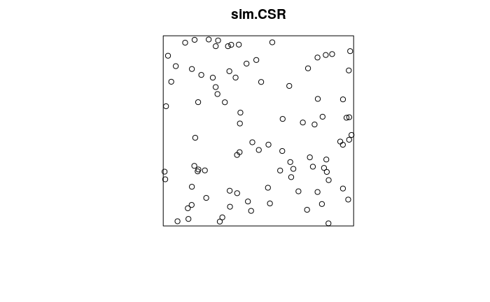

```r
plot(sim.CSR)
```

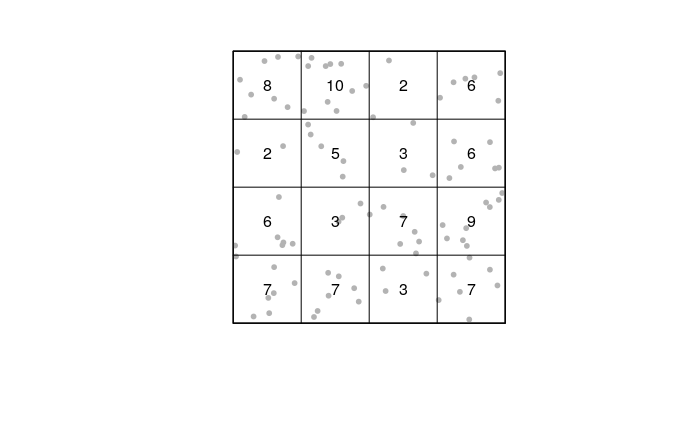

```r
# Quadrat Count
Q <- quadratcount(sim.CSR, nx= 4, ny=4)
plot(sim.CSR, pch=20, cols="grey70", main=NULL)  # Plot points
plot(Q, add=TRUE)  # Add quadrat grid
```

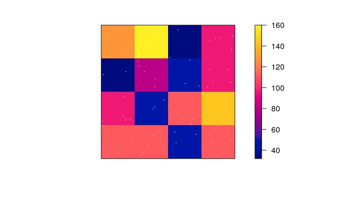

```r
# Quadrat Density
Q.d <- intensity(Q)
plot(intensity(Q, image=TRUE), main=NULL, las=1)  # Plot density raster
plot(sim.CSR, pch=1, cex=0.01, col="grey", add=TRUE)  # Add points
```

Test de uniformidad de distribucion PP Homogeneo

```r
QT <- quadrat.test(sim.CSR, nx=4, ny=4)
QT
```

```
    Chi-squared test of CSR using quadrat counts

data:  sim.CSR
X2 = 16.077, df = 15, p-value = 0.7539
alternative hypothesis: two.sided

Quadrats: 4 by 4 grid of tiles
```

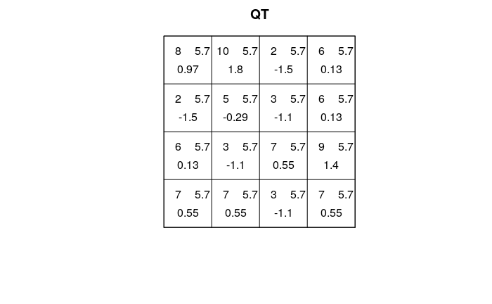

```r
plot(QT)
```

Analisis de Concentracion PP InHomogeneo

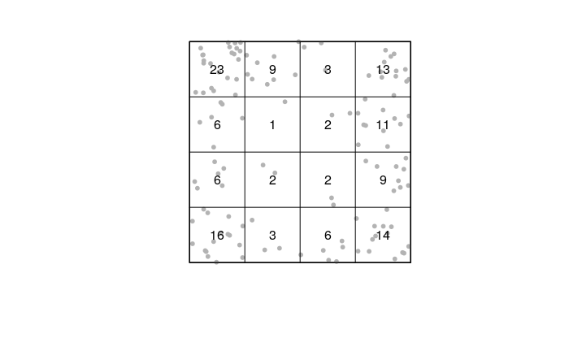

```r
# Quadrat Count
Q <- quadratcount(sim.INHa, nx= 4, ny=4)
plot(sim.INHa, pch=20, cols="grey70", main=NULL)  # Plot points
plot(Q, add=TRUE)  # Add quadrat grid
```

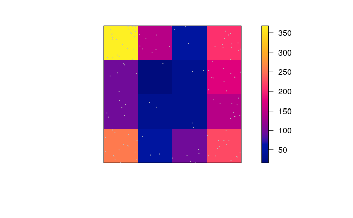

```r
# Quadrat Density
Q.d <- intensity(Q)
plot(intensity(Q, image=TRUE), main=NULL, las=1)  # Plot density raster
plot(sim.INHa, pch=1, cex=0.01, col="grey", add=TRUE)  # Add points
```

Test de uniformidad de distribucion PP InHomogeneo

```r
QT <- quadrat.test(sim.INHa, nx=4, ny=4)
QT
```

```
    Chi-squared test of CSR using quadrat counts

data:  sim.INHa
X2 = 73.619, df = 15, p-value = 2.009e-09
alternative hypothesis: two.sided

Quadrats: 4 by 4 grid of tiles
```

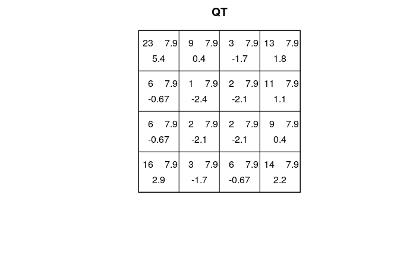

```r
plot(QT)
```

Proceso de Thomas

```r
par(mfrow=c(2,2))
par(mar=c(1,1,1,1))
set.seed(1)
inten<-30
disper<-0.02
mu<-10
sim.THO <- rThomas(inten,disper,mu)
plot(sim.THO,main=paste("Lambda=",inten,"Mu=",mu,"Sigma=",disper))
set.seed(1)
inten<-30
disper<-0.05
mu<-10
sim.THO <- rThomas(inten,disper,mu)
plot(sim.THO,main=paste("Lambda=",inten,"Mu=",mu,"Sigma=",disper))
```

```r
set.seed(1)
inten<-10
disper<-0.02
mu<-30
sim.THO <- rThomas(inten,disper,mu)
plot(sim.THO,main=paste("Lambda=",inten,"Mu=",mu,"Sigma=",disper))
set.seed(1)
inten<-10
disper<-0.05
mu<-30
sim.THO <- rThomas(inten,disper,mu)
plot(sim.THO,main=paste("Lambda=",inten,"Mu=",mu,"Sigma=",disper))
```

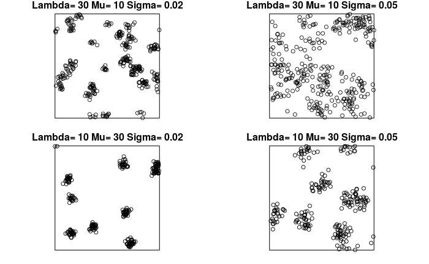

```r
par(mfrow=c(1,1))
```

Proceso de Secuencial Inhibicion Simple (SSI)

```r
par(mfrow=c(2,2))
par(mar=c(1,1,1,1))
set.seed(1)
delta<-0.01
sim.SSI <- rSSI(delta,100)
plot(sim.SSI,main=paste("n=100 delta=",delta))
set.seed(1)
delta<-0.05
sim.SSIa <- rSSI(delta,100)
plot(sim.SSIa,main=paste("n=100 delta=",delta))
```

```r
set.seed(1)
delta<-0.1
sim.SSI <- rSSI(delta,100)
```

```
Gave up after 1000 attempts with only 69 points placed out of 100
```

```r
plot(sim.SSI,main=paste("n=100 delta=",delta))
set.seed(1)
delta<-0.2
sim.SSIb <- rSSI(delta,100)
```

```
Window is too small to fit 100 points at minimum separation 0.2 (absolute maximum number is 31)Gave up after 1000 attempts with only 21 points placed out of 100
```

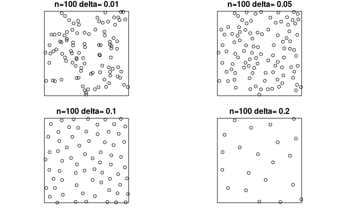

```r
plot(sim.SSIb,main=paste("n=100 delta=",delta))
```

Procesos de COX

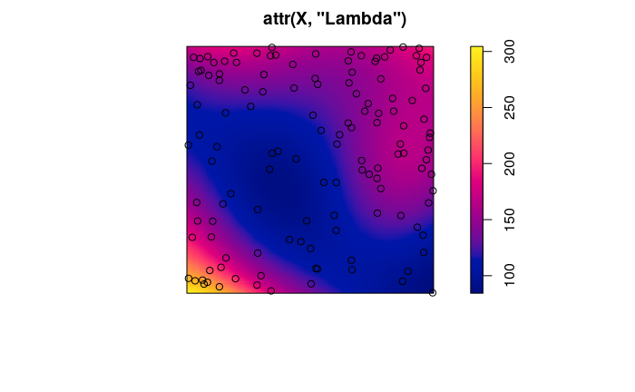

```r
library(RandomFields)
library(RandomFieldsUtils)
m <- as.im(function(x, y){5 - 1.5 * (x - 0.5)^2 + 2 * (y - 0.5)^2}, W=owin())
X <- rLGCP("gauss", m, var=0.15, scale =0.5)
plot(attr(X, "Lambda"))
points(X)
```

La Funcion G y F en CSR

```r
par(mfrow=c(1,3))
plot(sim.CSR)
env.CSR <- envelope(sim.CSR, fun = Gest, nsim = 200,nrank=5)
```

```
Generating 200 simulations of CSR  ...
1, 2, 3, 4.6.8.10.12.14.16.18.20.22.24.26.28.30.32.34.36.38.40.42.44.46.48
.50.52.54.56.58.60.62.64.66.68.70.72.74.76.78.80.82.84.86.88.90.92.94.96
.98.100.102.104.106.108.110.112.114.116.118.120.122.124.126.128.130.132.134.136.138.140.142.144
.146.148.150.152.154.156.158.160.162.164.166.168.170.172.174.176.178.180.182.184.186.188.190.192
.194.196.198. 200.

Done.
```

```r
plot(env.CSR)
```

```r
env.CSR <- envelope(sim.CSR, fun = Fest, nsim = 200,nrank=5)
```

```
Generating 200 simulations of CSR  ...
1, 2, 3, 4.6.8.10.12.14.16.18.20.22.24.26.28.30.32.34.36.38.40.42.44.46.48
.50.52.54.56.58.60.62.64.66.68.70.72.74.76.78.80.82.84.86.88.90.92.94.96
.98.100.102.104.106.108.110.112.114.116.118.120.122.124.126.128.130.132.134.136.138.140.142.144
.146.148.150.152.154.156.158.160.162.164.166.168.170.172.174.176.178.180.182.184.186.188.190.192
.194.196.198. 200.

Done.
```

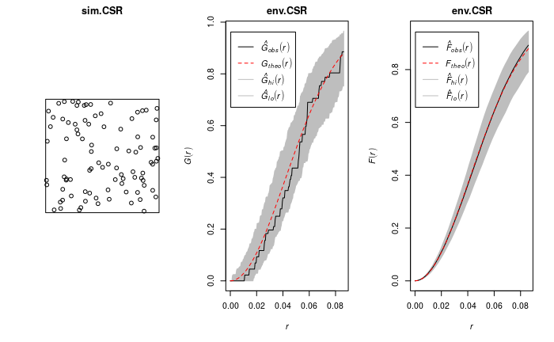

```r
plot(env.CSR)
par(mfrow=c(1,1))
```

La Funcion G y F en Thomas (Concentracion)

```r
par(mfrow=c(1,3))
plot(sim.THO)
env.THO <- envelope(sim.THO, fun = Gest, nsim = 200,nrank=5)
```

```
Generating 200 simulations of CSR  ...
1, 2, 3, 4.6.8.10.12.14.16.18.20.22.24.26.28.30.32.34.36.38.40.42.44.46.48
.50.52.54.56.58.60.62.64.66.68.70.72.74.76.78.80.82.84.86.88.90.92.94.96
.98.100.102.104.106.108.110.112.114.116.118.120.122.124.126.128.130.132.134.136.138.140.142.144
.146.148.150.152.154.156.158.160.162.164.166.168.170.172.174.176.178.180.182.184.186.188.190.192
.194.196.198. 200.

Done.
```

```r
plot(env.THO)
```

```r
env.THO <- envelope(sim.THO, fun = Fest, nsim = 200,nrank=5)
```

```
Generating 200 simulations of CSR  ...
1, 2, 3, 4.6.8.10.12.14.16.18.20.22.24.26.28.30.32.34.36.38.40.42.44.46.48
.50.52.54.56.58.60.62.64.66.68.70.72.74.76.78.80.82.84.86.88.90.92.94.96
.98.100.102.104.106.108.110.112.114.116.118.120.122.124.126.128.130.132.134.136.138.140.142.144
.146.148.150.152.154.156.158.160.162.164.166.168.170.172.174.176.178.180.182.184.186.188.190.192
.194.196.198. 200.

Done.
```

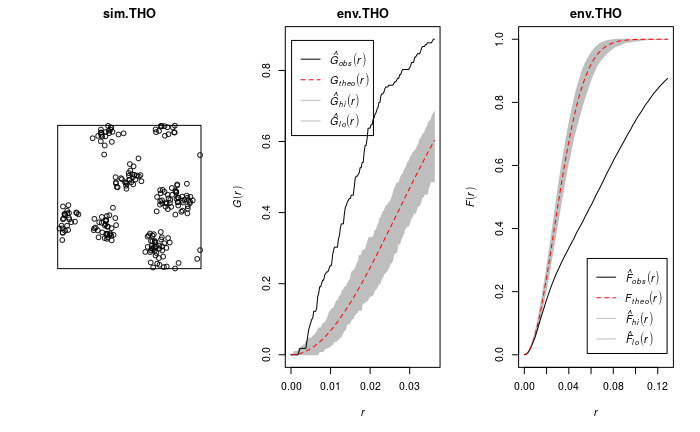

```r
plot(env.THO)
par(mfrow=c(1,1))
```

La Funcion G y F en SSI (Regularidad)

```r
par(mfrow=c(1,3))
sim.SSI<-sim.SSIa
plot(sim.SSI)
env.SSI <- envelope(sim.SSI, fun = Gest, nsim = 200,nrank=5)
```

```
Generating 200 simulations of CSR  ...
1, 2, 3, 4.6.8.10.12.14.16.18.20.22.24.26.28.30.32.34.36.38.40.42.44.46.48
.50.52.54.56.58.60.62.64.66.68.70.72.74.76.78.80.82.84.86.88.90.92.94.96
.98.100.102.104.106.108.110.112.114.116.118.120.122.124.126.128.130.132.134.136.138.140.142.144
.146.148.150.152.154.156.158.160.162.164.166.168.170.172.174.176.178.180.182.184.186.188.190.192
.194.196.198. 200.

Done.
```

```r
plot(env.SSI)
```

```r
env.SSI <- envelope(sim.SSI, fun = Fest, nsim = 200,nrank=5)
```

```
Generating 200 simulations of CSR  ...
1, 2, 3, 4.6.8.10.12.14.16.18.20.22.24.26.28.30.32.34.36.38.40.42.44.46.48
.50.52.54.56.58.60.62.64.66.68.70.72.74.76.78.80.82.84.86.88.90.92.94.96
.98.100.102.104.106.108.110.112.114.116.118.120.122.124.126.128.130.132.134.136.138.140.142.144
.146.148.150.152.154.156.158.160.162.164.166.168.170.172.174.176.178.180.182.184.186.188.190.192
.194.196.198. 200.

Done.
```

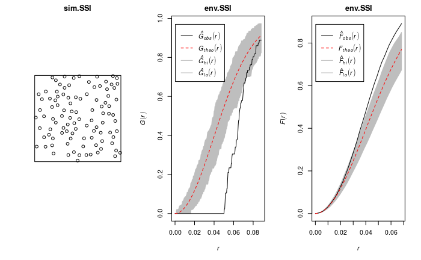

```r
plot(env.SSI)
par(mfrow=c(1,1))
```

```r
par(mfrow=c(1,3))
plot(sim.CSR)
env.CSR <- envelope(sim.CSR, fun = Kest, nsim = 200,nrank=5)
```

```
Generating 200 simulations of CSR  ...
1, 2, 3, 4.6.8.10.12.14.16.18.20.22.24.26.28.30.32.34.36.38.40.42.44.46.48
.50.52.54.56.58.60.62.64.66.68.70.72.74.76.78.80.82.84.86.88.90.92.94.96
.98.100.102.104.106.108.110.112.114.116.118.120.122.124.126.128.130.132.134.136.138.140.142.144
.146.148.150.152.154.156.158.160.162.164.166.168.170.172.174.176.178.180.182.184.186.188.190.192
.194.196.198. 200.

Done.
```

```r
plot(env.CSR)
```

```r
env.CSR <- envelope(sim.CSR, fun = Lest, nsim = 200,nrank=5)
```

```
Generating 200 simulations of CSR  ...
1, 2, 3, 4.6.8.10.12.14.16.18.20.22.24.26.28.30.32.34.36.38.40.42.44.46.48
.50.52.54.56.58.60.62.64.66.68.70.72.74.76.78.80.82.84.86.88.90.92.94.96
.98.100.102.104.106.108.110.112.114.116.118.120.122.124.126.128.130.132.134.136.138.140.142.144
.146.148.150.152.154.156.158.160.162.164.166.168.170.172.174.176.178.180.182.184.186.188.190.192
.194.196.198. 200.

Done.
```

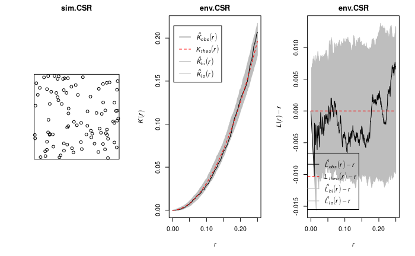

```r
plot(env.CSR, . -r ~ r)
par(mfrow=c(1,1))
```

La Funcion K y L en Thomas

```r
par(mfrow=c(1,3))
plot(sim.THO)
env.THO <- envelope(sim.THO, fun = Kest, nsim = 200,nrank=5)
```

```
Generating 200 simulations of CSR  ...
1, 2, 3, 4.6.8.10.12.14.16.18.20.22.24.26.28.30.32.34.36.38.40.42.44.46.48
.50.52.54.56.58.60.62.64.66.68.70.72.74.76.78.80.82.84.86.88.90.92.94.96
.98.100.102.104.106.108.110.112.114.116.118.120.122.124.126.128.130.132.134.136.138.140.142.144
.146.148.150.152.154.156.158.160.162.164.166.168.170.172.174.176.178.180.182.184.186.188.190.192
.194.196.198. 200.

Done.
```

```r
plot(env.THO)
```

```r
env.THO <- envelope(sim.THO, fun = Lest, nsim = 200,nrank=5)
```

```
Generating 200 simulations of CSR  ...
1, 2, 3, 4.6.8.10.12.14.16.18.20.22.24.26.28.30.32.34.36.38.40.42.44.46.48
.50.52.54.56.58.60.62.64.66.68.70.72.74.76.78.80.82.84.86.88.90.92.94.96
.98.100.102.104.106.108.110.112.114.116.118.120.122.124.126.128.130.132.134.136.138.140.142.144
.146.148.150.152.154.156.158.160.162.164.166.168.170.172.174.176.178.180.182.184.186.188.190.192
.194.196.198. 200.

Done.
```

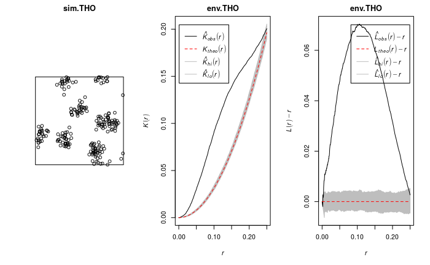

```r
plot(env.THO, . -r ~ r)
par(mfrow=c(1,1))
```

La Funcion K y L en SSI

```r
par(mfrow=c(1,3))
sim.SSI<-sim.SSIa
plot(sim.SSI)
env.SSI <- envelope(sim.SSI, fun = Kest, nsim = 200,nrank=5)
```

```
Generating 200 simulations of CSR  ...
1, 2, 3, 4.6.8.10.12.14.16.18.20.22.24.26.28.30.32.34.36.38.40.42.44.46.48
.50.52.54.56.58.60.62.64.66.68.70.72.74.76.78.80.82.84.86.88.90.92.94.96
.98.100.102.104.106.108.110.112.114.116.118.120.122.124.126.128.130.132.134.136.138.140.142.144
.146.148.150.152.154.156.158.160.162.164.166.168.170.172.174.176.178.180.182.184.186.188.190.192
.194.196.198. 200.

Done.
```

```r
plot(env.SSI)
```

```r
env.SSI <- envelope(sim.SSI, fun = Lest, nsim = 200,nrank=5)
```

```
Generating 200 simulations of CSR  ...
1, 2, 3, 4.6.8.10.12.14.16.18.20.22.24.26.28.30.32.34.36.38.40.42.44.46.48
.50.52.54.56.58.60.62.64.66.68.70.72.74.76.78.80.82.84.86.88.90.92.94.96
.98.100.102.104.106.108.110.112.114.116.118.120.122.124.126.128.130.132.134.136.138.140.142.144
.146.148.150.152.154.156.158.160.162.164.166.168.170.172.174.176.178.180.182.184.186.188.190.192
.194.196.198. 200.

Done.
```

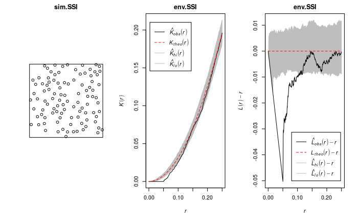

```r
plot(env.SSI, . -r ~ r)
par(mfrow=c(1,1))
```

Fry Plots o graficos de Petterson

```r
par(mfrow=c(2,3))
par(mar=c(1,1,1,1))
plot(sim.CSR)
plot(sim.THO)
```

```r
plot(sim.SSIb)
fryplot(sim.CSR)
```

```r
fryplot(sim.THO)
fryplot(sim.SSIb)
```

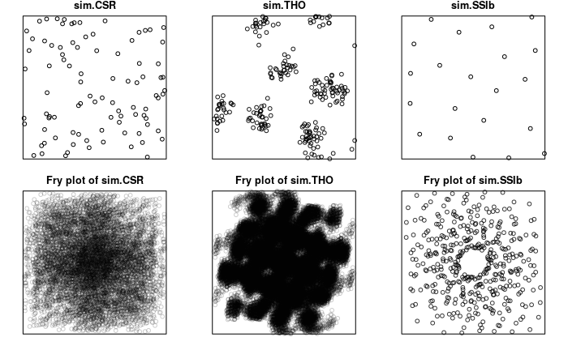

```r
par(mfrow=c(1,1))
```

Estimcion de la intensidad para poisson con modelo parametrico (funcion ppm)